# Self-organizing map analysis for event SRP yields at Wade

##### Decisions for eliminating remaining tricky variables by looking at PCA

- Variables are not transformed to improve normality
- Using Pearson correlation vs. covariance matrix given the untransformed data where vars have different units and ranges

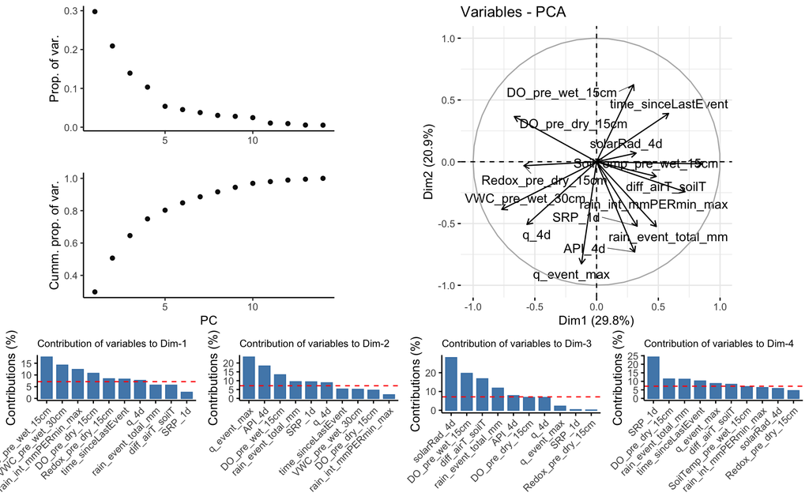

```r
myData <- wade_drop %>%
  # Keep only complete observations/rows (no NAs in any of the columns)
  na.omit()

# scale = TRUE = correlation matrix; scale = FALSE = covariance matrix
  PCA <- prcomp(myData, scale = TRUE, center = TRUE)
  pcaCharts(PCA)
```

#### Self-organizing map (SOM)

##### Prepare data & set up grid/lattice dimensions

We’re only using complete observations/rows (no NAs in any columns)  
According to the heuristic rule from Vesanto 2000, number of grid elements/grid size/nodes = 5 * sqrt(n)  
To determine the the shape of the grid (ratio of columns to rows), we use the ratio of the first two eigen values of the input data set as recommended by Park et al. 2006

```
## [1] No. of complete observations: 98 out of 120 observations
```

```
## [1] No. of Vesanto nodes: 49
```

```
## [1] Ratio of columns to rows: 1.4
```

##### Run SOM for a suite of grid/lattice configurations, # of nodes, and # of clusters

Code courtesy of Kristen Underwood (hidden)

```
## [1] Topology: hexagonal
```

```
## [1] Data normalization method used: L2norm
```

```
## [1] Weighting method used: noPCA
```

```
## [1] No. of iterations: 1500
```

```
## [1] alphaCrs used: 0.05
```

```
## [1] alphaFin used: 1500
```

##### Choose the best SOM run based on non-parametric F-stat and quantization error

We want to maximize npF (ratio of b/w cluster variance) and minimize QE (mean distance b/w each data vector & best-matching unit)  
Here are the top 50% of runs based on npF

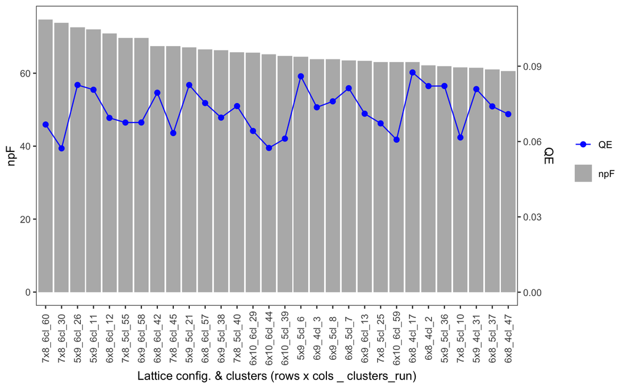

##### Choose the best run from each high performing (top 50%) cluster

| Run | rows | cols | Nodes | Clusters | npF | QE |
| --- | --- | --- | --- | --- | --- | --- |
| 3 | 6 | 9 | 54 | 4 | 63.850 | 0.074 |
| 55 | 7 | 8 | 56 | 5 | 69.713 | 0.068 |
| 30 | 7 | 8 | 56 | 6 | 73.828 | 0.057 |

To examine this run in greater detail (e.g., component planes), see the ‘X_SOMplots_site_ … .pdf’

##### 4 cluster model - examine boxplots of independent variables by cluster

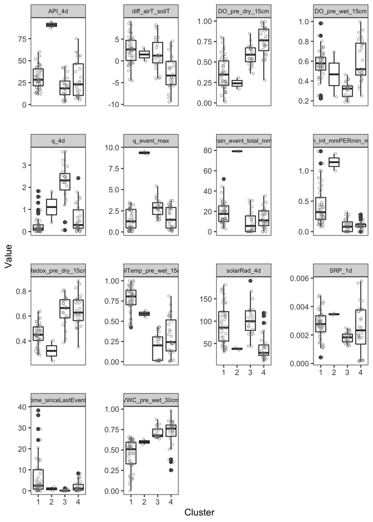

##### 4 cluster model - examine z-scores by cluster

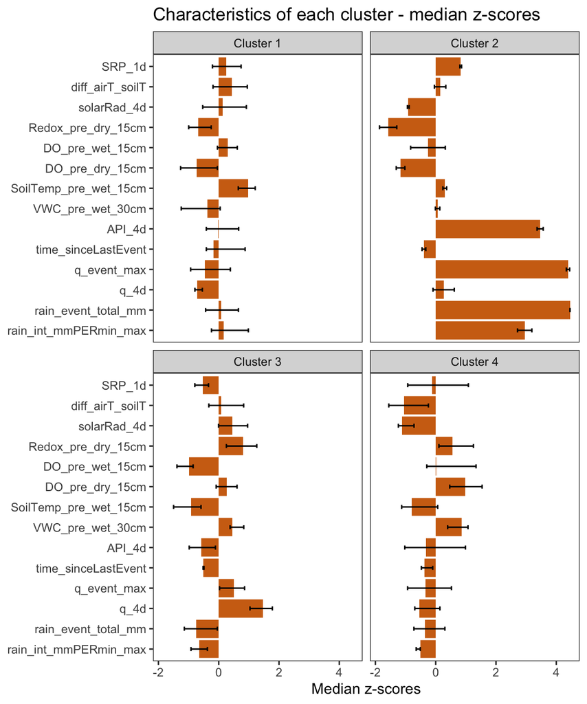

##### 5 cluster model - examine boxplots of independent variables by cluster

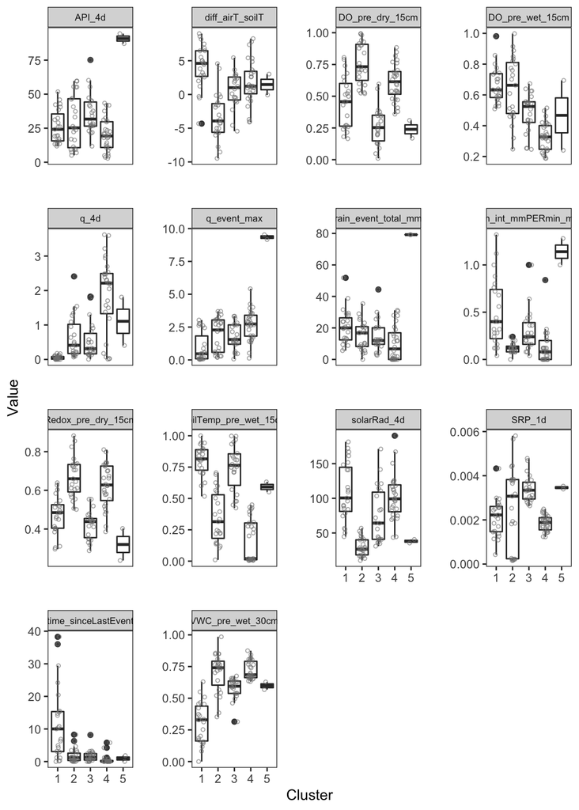

##### 5-cluster model - examine z-scores by cluster

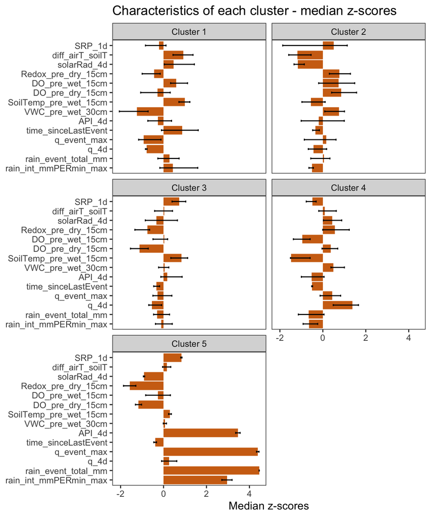

##### 6 cluster model - examine boxplots of independent variables by cluster

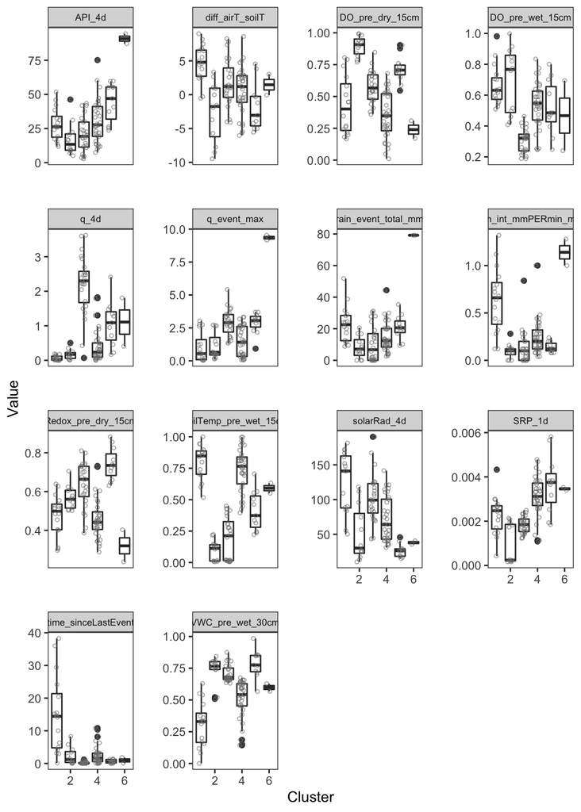

##### 6-cluster model - examine z-scores by cluster

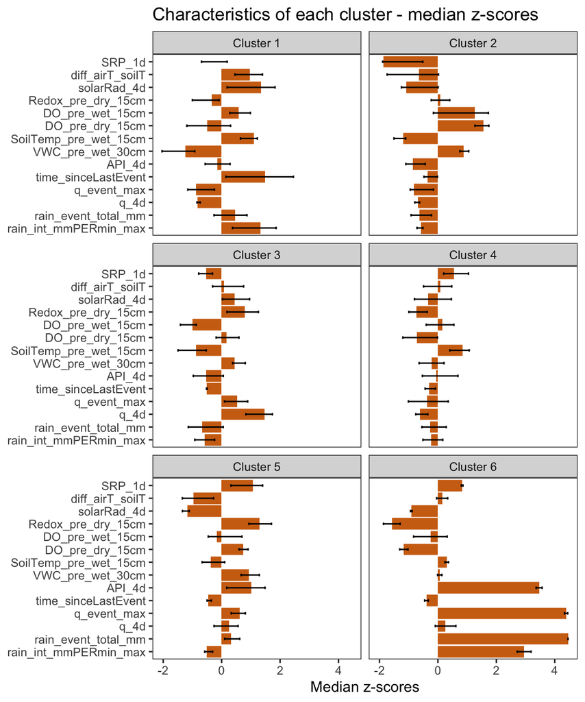